# Diamond Price Prediction

Ray Nelson

10/4/2018

## Sample from our tibble

Since our tibble has approximately 54,000 observations, we will first draw a random sample of 1000. This lays the ground work for when we partition our tibble into a training set and a testing set. It is also the basis for bootstrapping and jacknifing.

```r
set.seed(1234) # Needed so all get the sample random choice of observations
diamonds2 <- diamonds %>% sample_n(1000)
```

## First Step Scatterplot: Initial assessment of linear relationship and constant variance

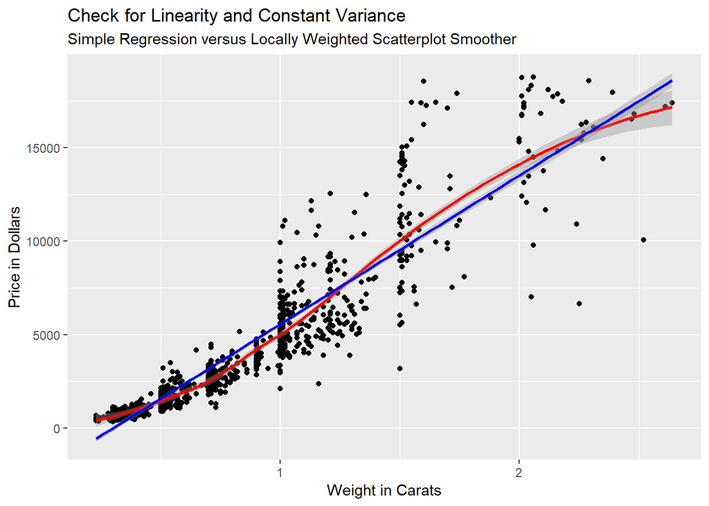

```r
diamonds2 %>% ggplot(aes(x = carat, y = price)) +
  geom_point() +
  geom_smooth(method = "loess", color = "red") +
  geom_smooth(method = "lm", color = "blue") +
  labs(
    title = "Check for Linearity and Constant Variance",
    subtitle = "Simple Regression versus Locally Weighted Scatterplot Smoother",
    x = "Weight in Carats",
    y = "Price in Dollars"
  )
```

## Look for relationships between price versus clarity, color, and cut

### Clarity

First let’s look at the distribution of clarity in our sample.

```r
diamonds2 %>% count(clarity)
```

```
## # A tibble: 8 x 2
##   clarity     n
##   <ord>   <int>
## 1 I1         12
## 2 SI2       170
## 3 SI1       243
## 4 VS2       230
## 5 VS1       147
## 6 VVS2       91
## 7 VVS1       70
## 8 IF         37
```

Notice that the most desirable clarity is IF, which category has only 37 out of 1000 observations in our sample.  
Now we can look at the violin plot with clarity ordered by the median price.

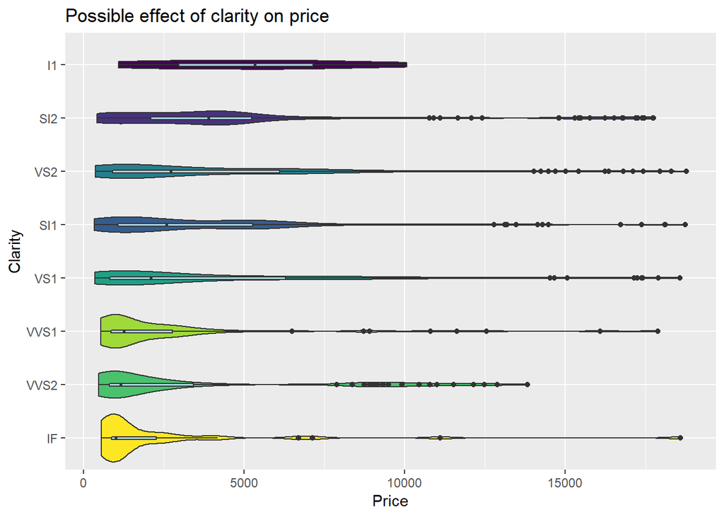

```r
diamonds2 %>% ggplot(aes(x = reorder(clarity, price, FUN = median), y = price)) +
  geom_violin(aes(fill = clarity), show.legend = FALSE) +
  geom_boxplot(width = 0.05, fill = "lightblue") +
  labs(title = "Possible effect of clarity on price",
  x = "Clarity",
  y = "Price") +
  coord_flip()
```

This gives the non-intuitive result that the most desirable category has the lowest price.

### Color

```r
diamonds2 %>% count(color)
```

```
## # A tibble: 7 x 2
##   color     n
##   <ord> <int>
## 1 D       131
## 2 E       194
## 3 F       145
## 4 G       189
## 5 H       182
## 6 I       107
## 7 J        52
```

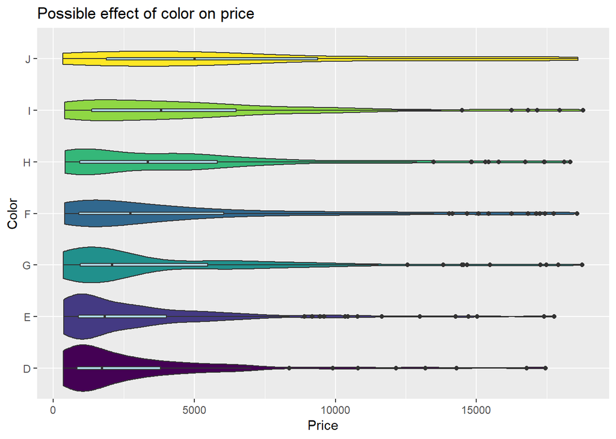

```r
diamonds2 %>% ggplot(aes(x = reorder(color, price, FUN = median), y = price)) +
  geom_violin(aes(fill = color), show.legend = FALSE) +
  geom_boxplot(width = 0.05, fill = "lightblue") +
  labs(title = "Possible effect of color on price",
       x = "Color",
       y = "Price") +
  coord_flip()
```

### Cut

```r
diamonds2 %>% count(cut)
```

```
## # A tibble: 5 x 2
##   cut           n
##   <ord>     <int>
## 1 Fair         34
## 2 Good         83
## 3 Very Good   221
## 4 Premium     268
## 5 Ideal       394
```

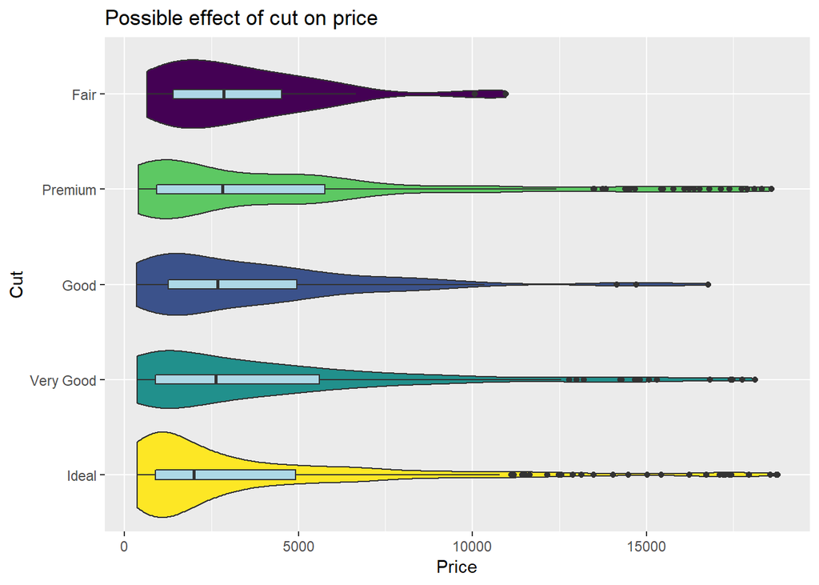

```r
diamonds2 %>% ggplot(aes(x = reorder(cut, price, FUN = median), y = price)) +
  geom_violin(aes(fill = cut), show.legend = FALSE) +
  geom_boxplot(width = 0.1, fill = "lightblue") +
  labs(title = "Possible effect of cut on price",
       x = "Cut",
       y = "Price") +
  coord_flip()
```

## Three Potential Problems

- Unexpected relationship between price and clarity
- Unexpected relationship between price and cut
- Unequal variance

## Lurking Variables

Let’s see if size is a lurking or confounding variable for the price versus clarity and price versus cut anomolies.

### Size by clarity

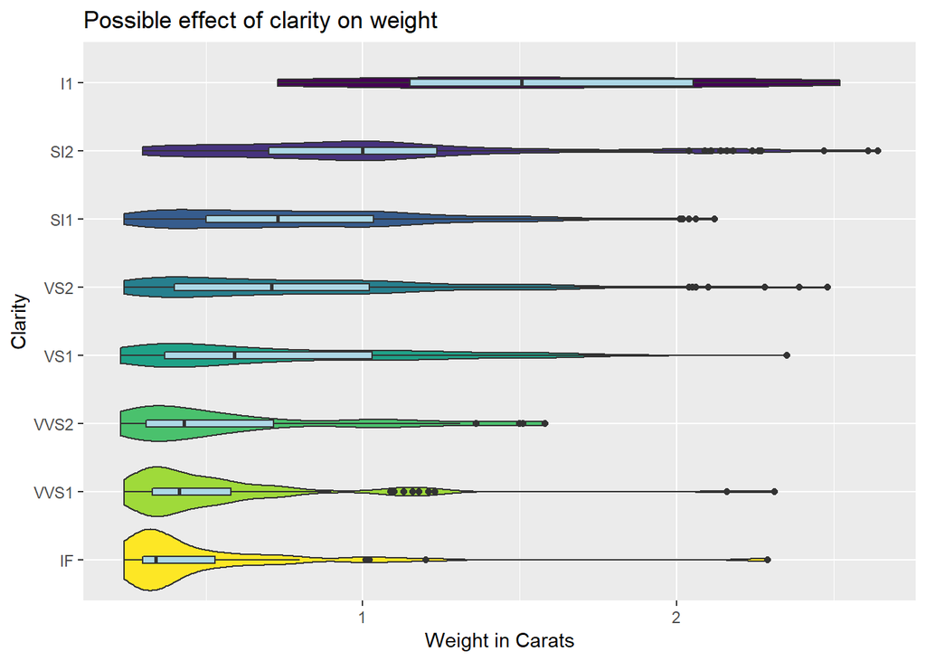

```r
diamonds2 %>% ggplot(aes(x = reorder(clarity, carat, FUN = median), y = carat)) +
  geom_violin(aes(fill = clarity), show.legend = FALSE) +
  geom_boxplot(width = 0.1, fill = "lightblue") +
  labs(title = "Possible effect of clarity on weight",
       x = "Clarity",
       y = "Weight in Carats") +
  coord_flip()
```

### Size by cut

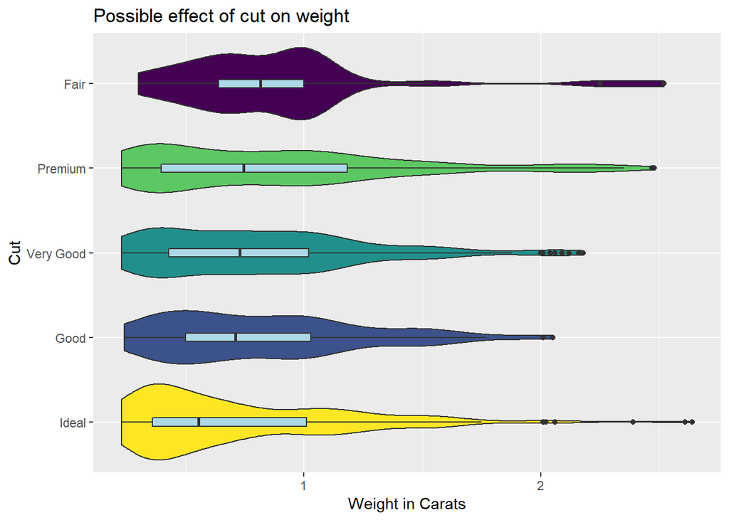

```r
diamonds2 %>% ggplot(aes(x = reorder(cut, carat, FUN = median), y = carat)) +
  geom_violin(aes(fill = cut), show.legend = FALSE) +
  geom_boxplot(width = 0.1, fill = "lightblue") +
  labs(title = "Possible effect of cut on weight",
       x = "Cut",
       y = "Weight in Carats") +
  coord_flip()
```

## Fix the nonconstant variance problem first.

See if a logarithmic transformation will cause variance to be similar.

### Natural Log of Price

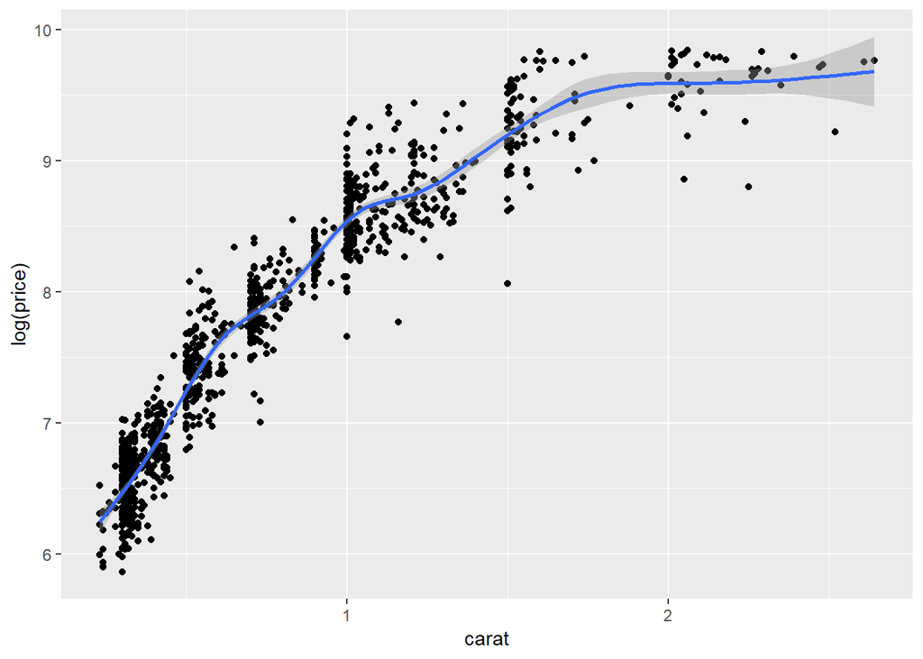

```r
diamonds2 %>% ggplot(aes(x = carat, y = log(price))) +
  geom_point() +
  geom_smooth()
```

### Natural Log of Carat

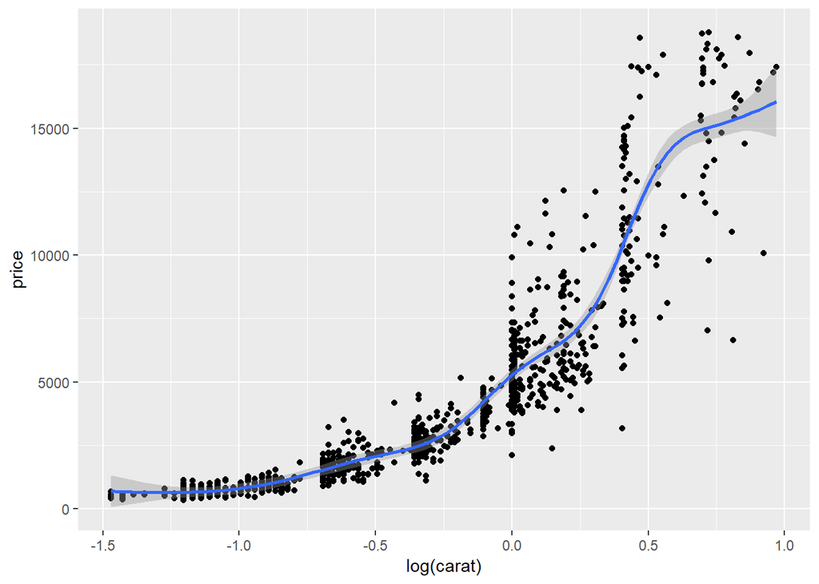

```r
diamonds2 %>% ggplot(aes(x = log(carat), y = price)) +
  geom_point() +
  geom_smooth()
```

### Natural Log of Price and Natural Log of Carat

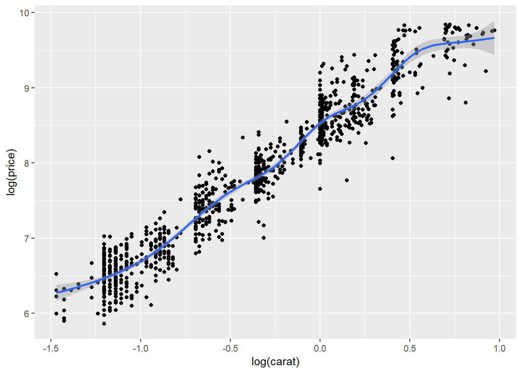

```r
diamonds2 %>% ggplot(aes(x = log(carat), y = log(price))) +
  geom_point() +
  geom_smooth()
```

## Remove the possible confounding effect of the size of the diamonds by running a simple regression using the natural logarithmic transformations.

```r
model <- lm(log(price) ~ log(carat), data = diamonds2)
```

### Calculate the residuals and add them to the diamonds2 tibble

```r
diamonds2 <- diamonds2 %>%
  add_residuals(model) %>%
  mutate(resid = exp(resid))
```

### Scatterplot of residuals by diamond size

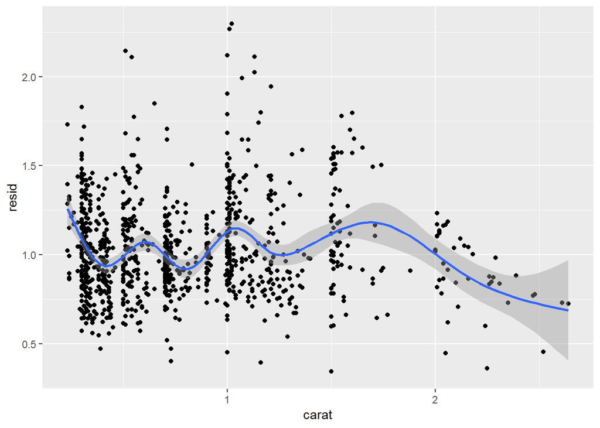

```r
diamonds2 %>% ggplot(mapping = aes(x = carat, y = resid)) +
  geom_point() +
  geom_smooth()
```

### Violin plot of prices by cut after the effect of weight has been removed

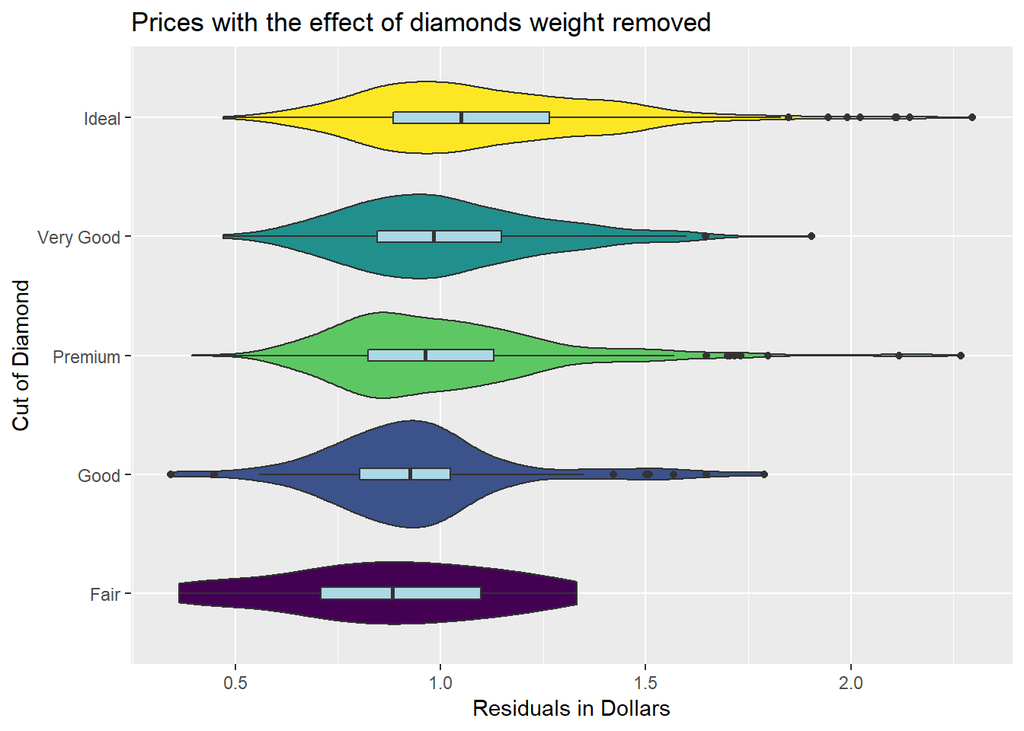

```r
diamonds2 %>% ggplot(aes(x = reorder(cut, resid, FUN = median), y = resid)) +
  geom_violin(aes(fill = cut), show.legend = FALSE) +
  geom_boxplot(width = 0.1, fill = "lightblue") +
  labs(title = "Prices with the effect of diamonds weight removed",
       x = "Cut of Diamond",
       y = "Residuals in Dollars") +
  coord_flip()
```

### Violin plot of prices by clarity after the effect of diamond weight has been removed

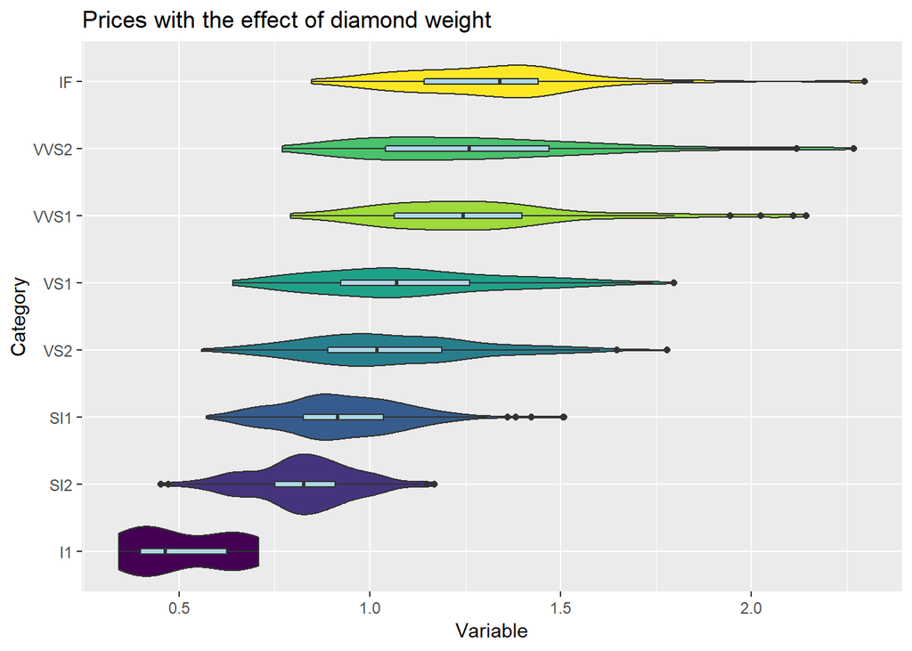

```r
diamonds2 %>% ggplot(aes(x = reorder(clarity, resid, FUN = median), y = resid)) +
  geom_violin(aes(fill = clarity), show.legend = FALSE) +
  geom_boxplot(width = 0.08, fill = "lightblue") +
  labs(title = "Prices with the effect of diamond weight",
       x = "Category",
       y = "Variable") +
  coord_flip()
```

## Do regression lines by categories share the same intercept and slope?

### Scatterplots of price on weight for each clarity category.

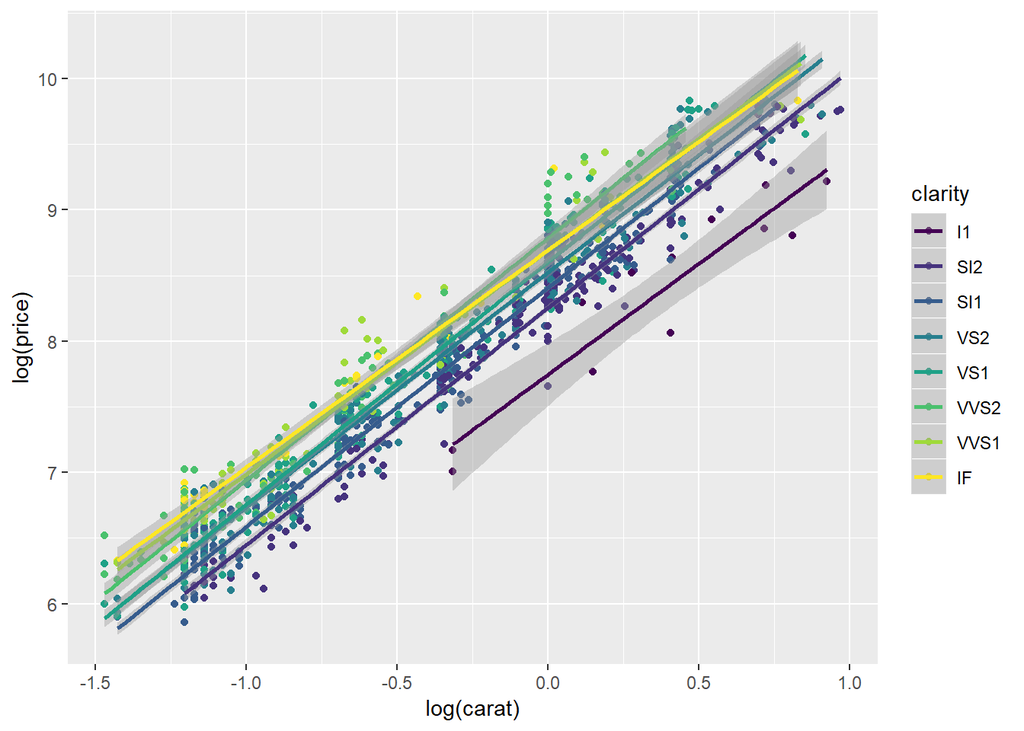

```r
diamonds2 %>% ggplot(aes(x = log(carat), y = log(price), color = clarity)) +
  geom_point() +
  geom_smooth(method = "lm")
```

### Scatterplots of price on weight for each color category.

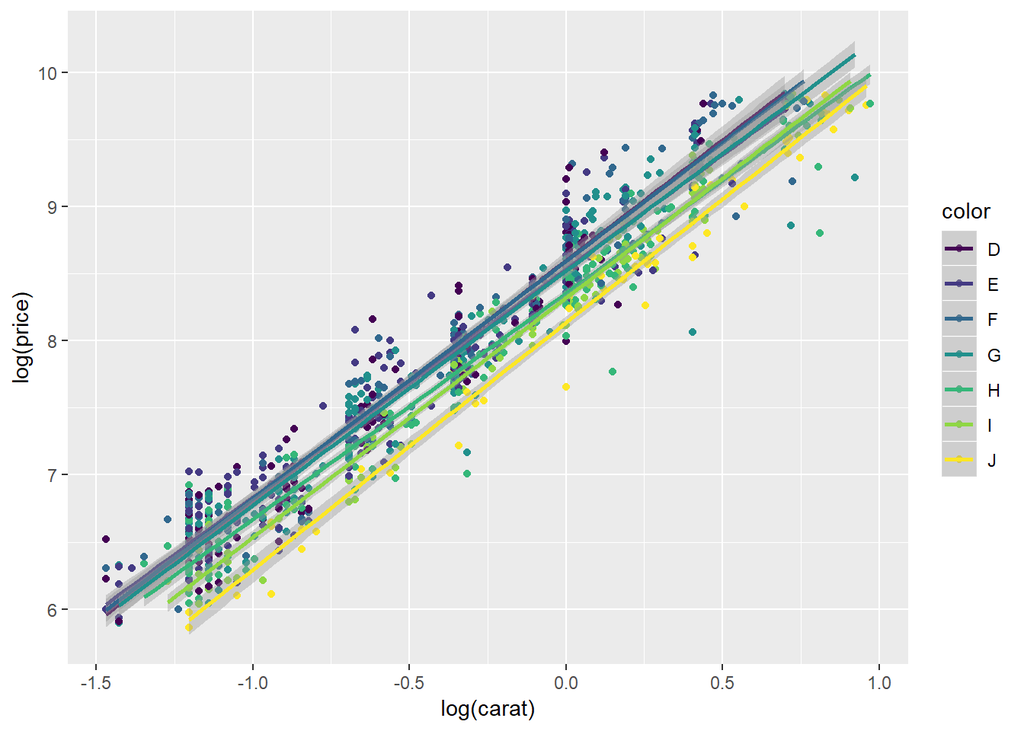

```r
diamonds2 %>% ggplot(aes(x = log(carat), y = log(price), color = color)) +
  geom_point() +
  geom_smooth(method = "lm")
```

### Scatterplots of price on weight for each cut category.

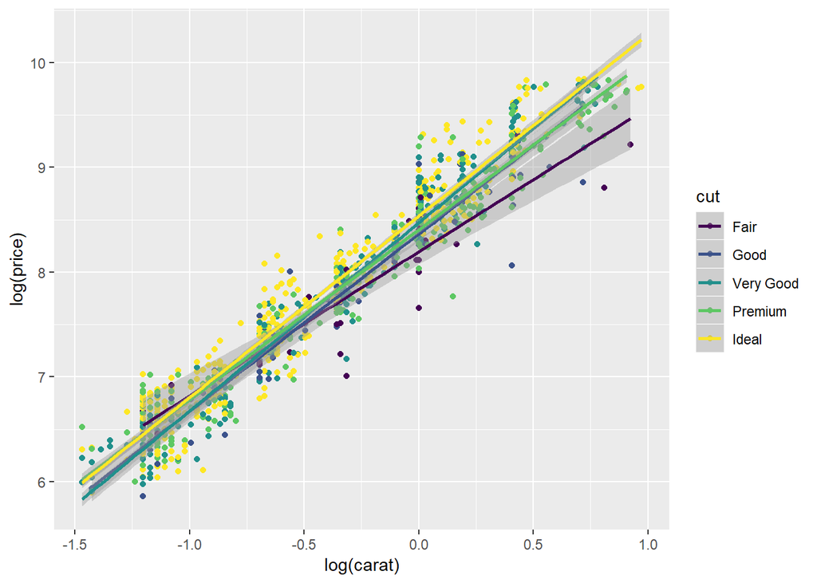

```r
diamonds2 %>% ggplot(aes(x = log(carat), y = log(price), color = cut)) +
  geom_point() +
  geom_smooth(method = "lm")
```

## Prediction of diamond prices

### Fit the prediction model using multiple regression

We can predict a diamonds price by fitting a linear model that includes the effects of weight, clarity, color, and cut.

```r
model <- lm(log(price) ~ log(carat) + clarity + color + cut + cut * log(carat),
            data = diamonds2)
model %>% summary()
```

```
##
## Call:
## lm(formula = log(price) ~ log(carat) + clarity + color + cut +
##     cut * log(carat), data = diamonds2)
##
## Residuals:
##      Min       1Q   Median       3Q      Max
## -0.48782 -0.08394  0.00440  0.08440  0.38492
##
## Coefficients:
##                    Estimate Std. Error  t value Pr(>|t|)
## (Intercept)       8.4450699  0.0084267 1002.179  < 2e-16 ***
## log(carat)        1.8738409  0.0130397  143.703  < 2e-16 ***
## clarity.L         0.9520035  0.0270983   35.131  < 2e-16 ***
## clarity.Q        -0.3112949  0.0253510  -12.279  < 2e-16 ***
## clarity.C         0.1800729  0.0214780    8.384  < 2e-16 ***
## clarity^4        -0.1239460  0.0169093   -7.330 4.82e-13 ***
## clarity^5         0.0574975  0.0134090    4.288 1.98e-05 ***
## clarity^6         0.0054250  0.0117345    0.462 0.643958
## clarity^7         0.0326780  0.0103406    3.160 0.001625 **
## color.L          -0.4471226  0.0146215  -30.580  < 2e-16 ***
## color.Q          -0.1029846  0.0134536   -7.655 4.64e-14 ***
## color.C           0.0017598  0.0123655    0.142 0.886860
## color^4          -0.0034148  0.0113368   -0.301 0.763316
## color^5          -0.0167200  0.0107495   -1.555 0.120170
## color^6           0.0008348  0.0100639    0.083 0.933906
## cut.L             0.1181024  0.0183369    6.441 1.86e-10 ***
## cut.Q            -0.0413156  0.0160830   -2.569 0.010350 *
## cut.C             0.0375384  0.0146002    2.571 0.010285 *
## cut^4             0.0086131  0.0121486    0.709 0.478506
## log(carat):cut.L  0.0453690  0.0339540    1.336 0.181799
## log(carat):cut.Q -0.0484284  0.0293264   -1.651 0.098988 .
## log(carat):cut.C  0.0833092  0.0248560    3.352 0.000834 ***
## log(carat):cut^4  0.0585455  0.0192358    3.044 0.002400 **
## ---
## Signif. codes:  0 '***' 0.001 '**' 0.01 '*' 0.05 '.' 0.1 ' ' 1
##
## Residual standard error: 0.1298 on 977 degrees of freedom
## Multiple R-squared:  0.9841, Adjusted R-squared:  0.9837
## F-statistic:  2750 on 22 and 977 DF,  p-value: < 2.2e-16
```

```r
model %>% anova()
```

```
## Analysis of Variance Table
##
## Response: log(price)
##                 Df Sum Sq Mean Sq   F value    Pr(>F)
## log(carat)       1 968.04  968.04 57443.934 < 2.2e-16 ***
## clarity          7  31.28    4.47   265.139 < 2.2e-16 ***
## color            6  18.47    3.08   182.676 < 2.2e-16 ***
## cut              4   0.91    0.23    13.458 1.108e-10 ***
## log(carat):cut   4   0.78    0.20    11.623 3.184e-09 ***
## Residuals      977  16.46    0.02
## ---
## Signif. codes:  0 '***' 0.001 '**' 0.01 '*' 0.05 '.' 0.1 ' ' 1
```

### Predict price of diamonds

The purpose of this analysis is to predict a diamond’s price based on its weight, clarity, color, and cut. We use the previous regression now to predict the price.

```r
carat <- 1
clarity <- "IF"
color <- "J"
cut <- "Ideal"

new_data <- data.frame(carat, cut, color, clarity)
predict(object = model, newdata = new_data, interval = "predict") %>% exp()
```

```
##        fit      lwr      upr
## 1 5416.185 4171.367 7032.481
```